# An Analysis of City of Chicago Employee Salaries

Brian Wang

July 2017

This data was obtained from https://www.datazar.com/file/f028ce9b8-6782-4d6d-9df1-743f8dca76a2 and accessed June 2017. The city of Chicago also provides a *slightly* more raw (and possibly more recently updated) version of this dataset [here.](https://data.cityofchicago.org/Administration-Finance/Current-Employee-Names-Salaries-and-Position-Title/xzkq-xp2w/data)

This dataset includes names, titles, departments, and salary information for all employees of the city of Chicago. Today, I’m going to import the data, perform some analyses and create some data visualizations.

## Data Import and Wrangling

```r
library(readr)
library(dplyr)
```

```r
library(tidyr)
library(stringr)
library(ggplot2)
library(DT)
salaries <- read_csv("../city-of-chicago-employee-salaries/salaries.csv", col_types = list(
  name = col_character(),
  position = col_character(),
  dept = col_character(),
  salary = col_character()))
```

```r
# Multiple plot function
#
# ggplot objects can be passed in ..., or to plotlist (as a list of ggplot objects)
# - cols:   Number of columns in layout
# - layout: A matrix specifying the layout. If present, 'cols' is ignored.
#
# If the layout is something like matrix(c(1,2,3,3), nrow=2, byrow=TRUE),
# then plot 1 will go in the upper left, 2 will go in the upper right, and
# 3 will go all the way across the bottom.
#
multiplot <- function(..., plotlist=NULL, file, cols=1, layout=NULL) {
  library(grid)

  # Make a list from the ... arguments and plotlist
  plots <- c(list(...), plotlist)

  numPlots = length(plots)

  # If layout is NULL, then use 'cols' to determine layout
  if (is.null(layout)) {
    # Make the panel
    # ncol: Number of columns of plots
    # nrow: Number of rows needed, calculated from # of cols
    layout <- matrix(seq(1, cols * ceiling(numPlots/cols)),
                    ncol = cols, nrow = ceiling(numPlots/cols))
  }

 if (numPlots==1) {
    print(plots[[1]])

  } else {
    # Set up the page
    grid.newpage()
    pushViewport(viewport(layout = grid.layout(nrow(layout), ncol(layout))))

    # Make each plot, in the correct location
    for (i in 1:numPlots) {
      # Get the i,j matrix positions of the regions that contain this subplot
      matchidx <- as.data.frame(which(layout == i, arr.ind = TRUE))

      print(plots[[i]], vp = viewport(layout.pos.row = matchidx$row,
                                      layout.pos.col = matchidx$col))
    }
  }
}
```

```r
dim(salaries)
```

```
## [1] 32062     4
```

```r
head(salaries)
```

```
## # A tibble: 6 × 4
##                  name                 position             dept
##                 <chr>                    <chr>            <chr>
## 1     AARON,  ELVIA J         WATER RATE TAKER      WATER MGMNT
## 2   AARON,  JEFFERY M           POLICE OFFICER           POLICE
## 3      AARON,  KARINA           POLICE OFFICER           POLICE
## 4 AARON,  KIMBERLEI R CHIEF CONTRACT EXPEDITER GENERAL SERVICES
## 5 ABAD JR,  VICENTE M        CIVIL ENGINEER IV      WATER MGMNT
## 6     ABARCA,  ANABEL     ASST TO THE ALDERMAN     CITY COUNCIL
## # ... with 1 more variables: salary <chr>
```

We examine the dimensions and `head` of the dataset to see that we have 32062 observations with these 4 variables each. We also see that the `salary` column should be converted to a numeric data type, but we first need to strip away the punctuation.

```r
# Convert salary variable to double after stripping away punctuation
salaries$salary <- str_replace(salaries$salary, "\\$", "")
salaries$salary <- str_replace(salaries$salary, ",", "")
salaries$salary <- as.double(salaries$salary)
# Alternate way to convert using single expression / regex
# salaries$salary <- as.double(
#  gsub("^\\$([1234567890]*),*([1234567890]*)\\.([1234567890]*)$", "\\1\\2\\.\\3", salaries$salary))
```

We check to make sure that the substitution worked correctly:

```r
head(salaries)
```

```
## # A tibble: 6 × 4
##                  name                 position             dept salary
##                 <chr>                    <chr>            <chr>  <dbl>
## 1     AARON,  ELVIA J         WATER RATE TAKER      WATER MGMNT  90744
## 2   AARON,  JEFFERY M           POLICE OFFICER           POLICE  84450
## 3      AARON,  KARINA           POLICE OFFICER           POLICE  84450
## 4 AARON,  KIMBERLEI R CHIEF CONTRACT EXPEDITER GENERAL SERVICES  89880
## 5 ABAD JR,  VICENTE M        CIVIL ENGINEER IV      WATER MGMNT 106836
## 6     ABARCA,  ANABEL     ASST TO THE ALDERMAN     CITY COUNCIL  70764
```

Looks good. I might also want to analyze the `name` column by last, first and middle name, so I’ll split the variable into three separate columns.

```r
# use regex to parse name column
names <- salaries$name

salaries <- salaries %>%
  separate(col = name,
           into = c("last", "first"),
           sep = ", ") %>%
  extract(col = first,
          into = c("first", "middle"),
          "([ABCDEFGHIJKLMNOPQRSTUVWXYZ]+)[ ]*([ABCDEFHIJKLMNOPQRSTUVWXYZ]*)")

salaries$name <- names

# if no middle name, fill middle field with NA
salaries$middle <- gsub("^$", NA, salaries$middle)
```

```r
head(salaries)
```

```
## # A tibble: 6 × 7
##      last     first middle                 position             dept
##     <chr>     <chr>  <chr>                    <chr>            <chr>
## 1   AARON     ELVIA      J         WATER RATE TAKER      WATER MGMNT
## 2   AARON   JEFFERY      M           POLICE OFFICER           POLICE
## 3   AARON    KARINA   <NA>           POLICE OFFICER           POLICE
## 4   AARON KIMBERLEI      R CHIEF CONTRACT EXPEDITER GENERAL SERVICES
## 5 ABAD JR   VICENTE      M        CIVIL ENGINEER IV      WATER MGMNT
## 6  ABARCA    ANABEL   <NA>     ASST TO THE ALDERMAN     CITY COUNCIL
## # ... with 2 more variables: salary <dbl>, name <chr>
```

I preserved the full `name` variable in case I want to plot the full name anywhere in a data visualization for some reason. Now that we have the data cleaned up, we can examine each variable individually for a few summary statistics.

## Examination of each variable

### What are the most common and least common first and last names?

```r
salaries %>%
  group_by("Last Name" = last) %>%
  summarise(Count = n(), Proportion = Count / nrow(salaries)) %>%
  arrange(desc(Count)) %>%
  datatable() %>% formatPercentage(3, 2)
```

|  | Last Name | Count | Proportion |
| --- | --- | --- | --- |
| 1 | WILLIAMS | 293 | 0.0091385440708627 |
| 2 | JOHNSON | 244 | 0.0076102551306843 |
| 3 | SMITH | 241 | 0.00751668642006113 |
| 4 | BROWN | 185 | 0.00577007048842867 |
| 5 | JONES | 183 | 0.00570769134801322 |
| 6 | RODRIGUEZ | 171 | 0.00533341650552055 |
| 7 | JACKSON | 136 | 0.00424178154825027 |
| 8 | GARCIA | 130 | 0.00405464412700393 |
| 9 | DAVIS | 127 | 0.00396107541638076 |
| 10 | HERNANDEZ | 110 | 0.00343085272284948 |

[output cut: 13820 more lines]

```r
# Count of number of last names that appear the least, by frequency
table(table(salaries$last))[1:10]
```

```
##
##    1    2    3    4    5    6    7    8    9   10
## 9750 1965  751  377  229  133   98   75   51   57
```

```r
# Percentage of last names that appear the least, by frequency
round(table(table(salaries$last)) / nrow(salaries),5)[1:10]
```

```
##
##       1       2       3       4       5       6       7       8       9
## 0.30410 0.06129 0.02342 0.01176 0.00714 0.00415 0.00306 0.00234 0.00159
##      10
## 0.00178
```

The top three most common last names across all Chicago city employees are Williams, Johnson, and Smith.

```r
salaries %>%
  group_by("First Name" = first) %>%
  summarise(Count = n(), Proportion = Count / nrow(salaries)) %>%
  arrange(desc(Count)) %>%
  datatable() %>% formatPercentage(3, 2)
```

|  | First Name | Count | Proportion |
| --- | --- | --- | --- |
| 1 | MICHAEL | 1153 | 0.0359615744495041 |
| 2 | JOHN | 900 | 0.0280706131869503 |
| 3 | JAMES | 676 | 0.0210841494604204 |
| 4 | ROBERT | 622 | 0.0193999126692034 |
| 5 | JOSEPH | 537 | 0.016748799201547 |
| 6 | DAVID | 506 | 0.0157819225251076 |
| 7 | THOMAS | 490 | 0.015282889401784 |
| 8 | DANIEL | 472 | 0.014721477138045 |
| 9 | WILLIAM | 397 | 0.0123822593724658 |
| 10 | ANTHONY | 385 | 0.0120079845299732 |

[output cut: 5062 more lines]

The top three most common first names across all Chicago city employees are Michael, John and James.

- 1153 people have the first name Michael, or 3.6% of all Chicago employees.
- 900 people have the first name John, or 2.81% of all Chicago employees.
- 676 people have the first name James, or 2.11% of all Chicago employees.

### What are the most common first letters of first and last names?

We can also do a little bit more interesting (even if meaningless) analysis of names by considering the first letters of each name.

```r
salaries <- salaries %>%
  mutate(firstletter = substring(first, 0, 1),
         last_firstletter = substring(last, 0, 1))

# Sort first letters of first names by frequency
sort(table(salaries$firstletter), decreasing = TRUE)
```

```
##
##    J    M    R    D    A    C    S    T    K    L    E    P    B    G    W
## 4564 3639 2599 2543 2312 1984 1859 1662 1425 1403 1321 1154 1132 1036  695
##    N    F    V    H    I    O    Y    Z    Q    U    X
##  628  505  503  411  225  168  144   73   42   23   12
```

```r
# Sort first letters of last names by frequency
sort(table(salaries$last_firstletter), decreasing = TRUE)
```

```
##
##    M    S    C    B    R    H    G    W    P    D    L    K    A    T    J
## 3215 2934 2584 2387 1943 1895 1869 1739 1591 1553 1432 1256 1187 1120 1098
##    F    O    N    V    E    Z    I    Y    Q    U    X
## 1021  727  595  580  539  301  160  160   93   76    7
```

The most common first letter of first names is J, while the most common first letter of last names is M.

- 4564 Chicago city employees have first names starting with the letter J.
- 3215 Chicago city employees have last names starting the letter M.

We can plot these results in a histogram in ggplot2. (It would be interesting to do further analysis on how these statistics might change when subsetting by department, or salary.)

```r
p1 <- salaries %>%
  ggplot(aes(x = firstletter, fill = ..count..)) +
  geom_bar(stat = "count") +
  geom_text(aes(label = ..count..),
            stat = "count",
            vjust = "inward",
            size = 2) +
  ggtitle("count of first letters of first names, chicago employees") +
  scale_y_continuous(expand = c(0.01, 0), limits = c(0, 4750)) +
  theme(legend.position = "none",
        axis.title.y = element_blank(),
        axis.title.x = element_blank(),
        axis.ticks.y = element_blank(),
        axis.text.y = element_blank(),
        plot.title = element_text(vjust = 0),
        panel.background = element_blank(),
        panel.grid.major = element_blank(),
        panel.grid.minor = element_line(color = "gray80"),
        panel.ontop = FALSE, # puts gridlines on top of data
        plot.background = element_rect(fill = "white", color = "black"),
        panel.border = element_rect(linetype = "dashed", fill = NA))

p2 <- salaries %>%
  ggplot(aes(x = last_firstletter, fill = ..count..)) +
  geom_bar() +
  geom_text(aes(label = ..count..),
            color = "black",
            stat = "count",
            size = 2,
            vjust = "inward") +
  ggtitle("count of first letters of last names, chicago employees") +
  scale_y_continuous(expand = c(0.01, 0)) +
  theme(legend.position = "none",
        axis.title.y = element_blank(),
        axis.title.x = element_blank(),
        axis.ticks.y = element_blank(),
        axis.text.y = element_blank(),
        plot.title = element_text(vjust = 0),
        panel.background = element_blank(),
        panel.grid.major = element_blank(),
        panel.grid.minor = element_line(color = "gray80"),
        panel.ontop = FALSE, # puts gridlines on top of data
        plot.background = element_rect(fill = "white", color = "black"),
        panel.border = element_rect(linetype = "dashed", fill = NA))
```

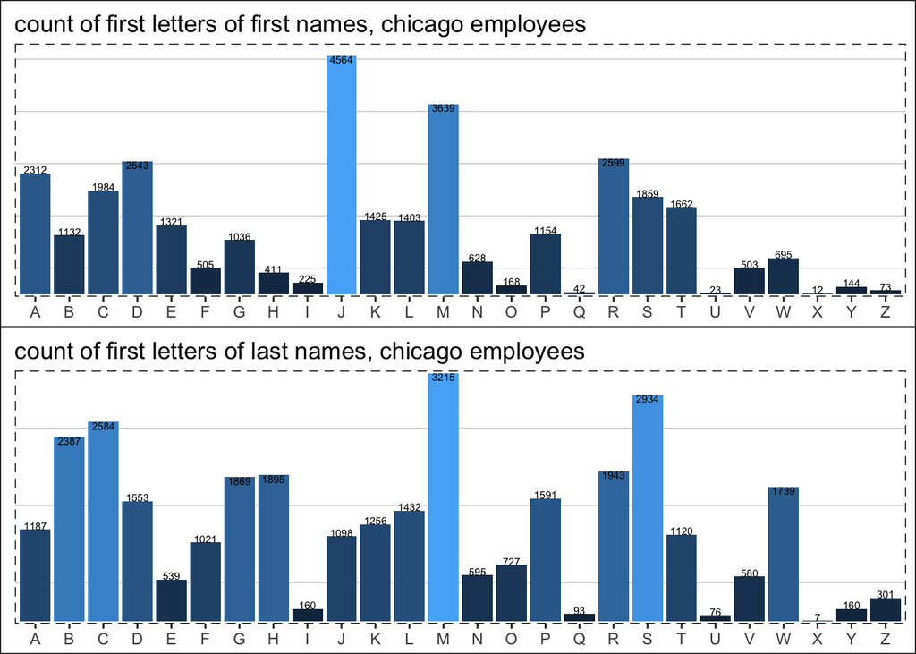

```r
multiplot(p1, p2)
```

### What departments have the most employees?

Let’s start by getting a list of all the departments:

```r
unique(salaries$dept)
```

```
##  [1] "WATER MGMNT"           "POLICE"
##  [3] "GENERAL SERVICES"      "CITY COUNCIL"
##  [5] "STREETS & SAN"         "OEMC"
##  [7] "AVIATION"              "FIRE"
##  [9] "FAMILY & SUPPORT"      "IPRA"
## [11] "PUBLIC LIBRARY"        "BUSINESS AFFAIRS"
## [13] "TRANSPORTN"            "HEALTH"
## [15] "MAYOR'S OFFICE"        "LAW"
## [17] "FINANCE"               "CULTURAL AFFAIRS"
## [19] "COMMUNITY DEVELOPMENT" "BUILDINGS"
## [21] "ANIMAL CONTRL"         "CITY CLERK"
## [23] "BOARD OF ELECTION"     "INSPECTOR GEN"
## [25] "TREASURER"             "DISABILITIES"
## [27] "HUMAN RESOURCES"       "DoIT"
## [29] "BUDGET & MGMT"         "PROCUREMENT"
## [31] "HUMAN RELATIONS"       "BOARD OF ETHICS"
## [33] "POLICE BOARD"          "ADMIN HEARNG"
## [35] "LICENSE APPL COMM"
```

There are 35 departments in this dataset.

```r
# Largest departments (by number of employees)
sort(table(salaries$dept), decreasing=TRUE)[1:5]
```

```
##
##        POLICE          FIRE STREETS & SAN          OEMC   WATER MGMNT
##         12618          4796          2152          1982          1840
```

```r
# Smallest departments (by number of employees)
sort(table(salaries$dept))[1:5]
```

```
##
## LICENSE APPL COMM      POLICE BOARD   BOARD OF ETHICS   HUMAN RELATIONS
##                 1                 2                 9                16
##         TREASURER
##                22
```

The top five departments (with the largest number of employees) are the police department, fire department, streets & sanitation, Office of Emergency Management and Communications, and water management.

The five smallest departments (with the smallest number of employees) are the license appeal commission, the police board, the board of ethics, HR, and the treasurer’s office.

The police department has the most employees (12,618), while the license application committee has the least employees (1).

### What are the most and least common job titles?

```r
# Most common job titles
sort(table(salaries$position), decreasing=TRUE)[1:5]
```

```
##
##                         POLICE OFFICER
##                                   9184
##                        FIREFIGHTER-EMT
##                                   1208
##                               SERGEANT
##                                   1185
##                POOL MOTOR TRUCK DRIVER
##                                    918
## POLICE OFFICER (ASSIGNED AS DETECTIVE)
##                                    896
```

```r
# Count of least common job titles by frequency
table(table(salaries$position))[1:5]
```

```
##
##   1   2   3   4   5
## 371 128  92  64  41
```

The most common job titles are police officer, firefighter, sergeant, pool motor truck driver, and police officer (detective).

There are 9,184 police officers, which is over 7 times the number of firefighter-EMTs (1,208). There are almost as many sergeants as the number of firefighter-EMTs (1,185).

There are 371 city employee positions that are unique, at least in title.

### What’s the mean, median, range of salaries in the city of Chicago?

We can perform a bit more rich analysis with our single numerical variable, the salary.

```r
salaries[which.max(salaries$salary),]
```

```
## # A tibble: 1 × 9
##    last  first middle                 position     dept salary
##   <chr>  <chr>  <chr>                    <chr>    <chr>  <dbl>
## 1 EVANS GINGER      S COMMISSIONER OF AVIATION AVIATION  3e+05
## # ... with 3 more variables: name <chr>, firstletter <chr>,
## #   last_firstletter <chr>
```

```r
salaries[which.min(salaries$salary),]
```

```
## # A tibble: 1 × 9
##    last  first middle                 position           dept salary
##   <chr>  <chr>  <chr>                    <chr>          <chr>  <dbl>
## 1  KOCH STEVEN   <NA> ADMINISTRATIVE SECRETARY MAYOR'S OFFICE   0.96
## # ... with 3 more variables: name <chr>, firstletter <chr>,
## #   last_firstletter <chr>
```

The city employee that makes the most is Ginger Evans, who makes an annual salary of $300,000 as the commissioner of aviation. Evans oversees both of the major international airports in Chicago, O’Hare and Midway International Airport.

The city employee that makes the least is Steven Koch, who is listed as an administrative secretary in the mayor’s office on a salary of $0.96/year. At first I thought that this was a mistake, but turns out that it’s not. Steven Koch is a former investment banker that assumed the deputy mayor’s position in 2012 to improve Chicago’s financial situation and attract new businesses to the city. He stated that his interest in the position was not about the salary, but about giving back. More information can be found at http://chicago.cbslocal.com/2012/08/06/new-deputy-mayor-to-work-on-improving-economy-for-just-1-per-year/.

Since Steven Koch is a bit of an outlier, let’s also make sure to look into who’s the *second* lowest paid employee. Turns out these are all employees in the Dept. of Family & Support, either working as foster grandparents or senior companions.

```r
salaries %>%
  arrange(salary)
```

```
## # A tibble: 32,062 × 9
##          last     first middle                 position             dept
##         <chr>     <chr>  <chr>                    <chr>            <chr>
## 1        KOCH    STEVEN   <NA> ADMINISTRATIVE SECRETARY   MAYOR'S OFFICE
## 2      ABBOTT     BETTY      L       FOSTER GRANDPARENT FAMILY & SUPPORT
## 3  ABDULWAHAB ABUUBAIDA   <NA>       FOSTER GRANDPARENT FAMILY & SUPPORT
## 4       ABREU    VICTOR   <NA>         SENIOR COMPANION FAMILY & SUPPORT
## 5     AL AMIN RASHEEDAH      K         SENIOR COMPANION FAMILY & SUPPORT
## 6   ALEXANDER      MARY      F       FOSTER GRANDPARENT FAMILY & SUPPORT
## 7    ANDERSON       ANN   <NA>         SENIOR COMPANION FAMILY & SUPPORT
## 8    ANDERSON    ROSLYN   <NA>       FOSTER GRANDPARENT FAMILY & SUPPORT
## 9   ARMSTRONG    LOUISE   <NA>         SENIOR COMPANION FAMILY & SUPPORT
## 10  AUGUSTAVE LAFONTANT      J       FOSTER GRANDPARENT FAMILY & SUPPORT
## # ... with 32,052 more rows, and 4 more variables: salary <dbl>,
## #   name <chr>, firstletter <chr>, last_firstletter <chr>
```

```r
summary(salaries$salary)
```

```
##      Min.   1st Qu.    Median      Mean   3rd Qu.      Max.
##      0.96  72860.00  84450.00  80200.00  93240.00 300000.00
```

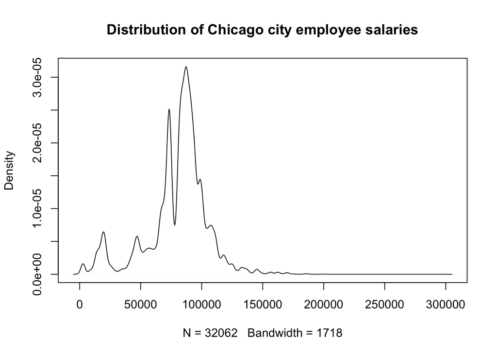

```r
plot(density(salaries$salary), main="Distribution of Chicago city employee salaries")
```

Plotting the density of employees salaries and examining the summary statistics, we also observe a few things.

- The distribution has multiple peaks, which I’m assuming may be due to standard salary schedules for certain positions
- Most of the distribution is concentrated around the mean. The distribution doesn’t exhibit any unusually strange patterns.
- The few employees with extremely high-salaries like Ginger Evans do not really skew the overall mean; in fact, the median salary is higher than the mean salary.

## Relationships between variables

Now that we’ve spent some time looking at each variable individually, we can try to explore some relationships between variables, for example -

- What department costs Chicago the most in terms of total salary paid?
- What department costs Chicago the most in terms of highest average salary per employee?
- Grouped by the letter your first name starts with, what letter has the highest average salary?

We start by computing the total salary paid per department and computing some summary statistics on salary by department.

```r
# Total salary paid per department (annual)
(salaries_summary <- salaries %>%
  group_by(dept) %>%
  summarise(sum = sum(salary), n = n(), mean = round(mean(salary), 2), sd = round(sd(salary), 2)) %>%
  arrange(desc(sd))) %>% datatable()
```

|  | dept | sum | n | mean | sd |
| --- | --- | --- | --- | --- | --- |
| 1 | MAYOR'S OFFICE | 7531148.96 | 86 | 87571.5 | 45450.85 |
| 2 | FAMILY &amp; SUPPORT | 26367348.4 | 654 | 40317.05 | 37437.87 |
| 3 | LAW | 30924123.8 | 414 | 74695.95 | 31474.66 |
| 4 | CITY COUNCIL | 22843048.56 | 396 | 57684.47 | 30016.37 |
| 5 | OEMC | 81217800.04 | 1982 | 40977.7 | 29841.1 |
| 6 | PUBLIC LIBRARY | 54108880.8 | 961 | 56304.77 | 28315.86 |
| 7 | CULTURAL AFFAIRS | 5950580 | 74 | 80413.24 | 27932.82 |
| 8 | TREASURER | 1991577 | 22 | 90526.23 | 27624.08 |
| 9 | BOARD OF ELECTION | 6572532 | 117 | 56175.49 | 25422.8 |
| 10 | POLICE BOARD | 159948 | 2 | 79974 | 25107.95 |

[output cut: 25 more lines]

The city of Chicago spends $2.6 billion on employee salaries annually. Of this, about $1.1 billion is spent on the police department and about $459 million is spent on the fire department.

If we look at the average salary per employee, the Department of Innovation and Technology (DoIT) has the highest mean salary of $96,727.29 with the buildings and fire department with the second and third highest mean salary.

As for a standard deviation of employee salaries within a department, the highest is in the mayor’s office, while the lowest is in the human relations (resources?) department. Other departments with a high standard deviation of salaries include the Family & Support department and Law department.

The police department actually has the third lowest standard deviation of departments in the dataset, most likely because of a standard salary schedule for officers.

I’m a bit curious about the high standard deviation of salaries in the mayor’s office, so let’s filter the salaries by the mayor’s office and sort/plot.

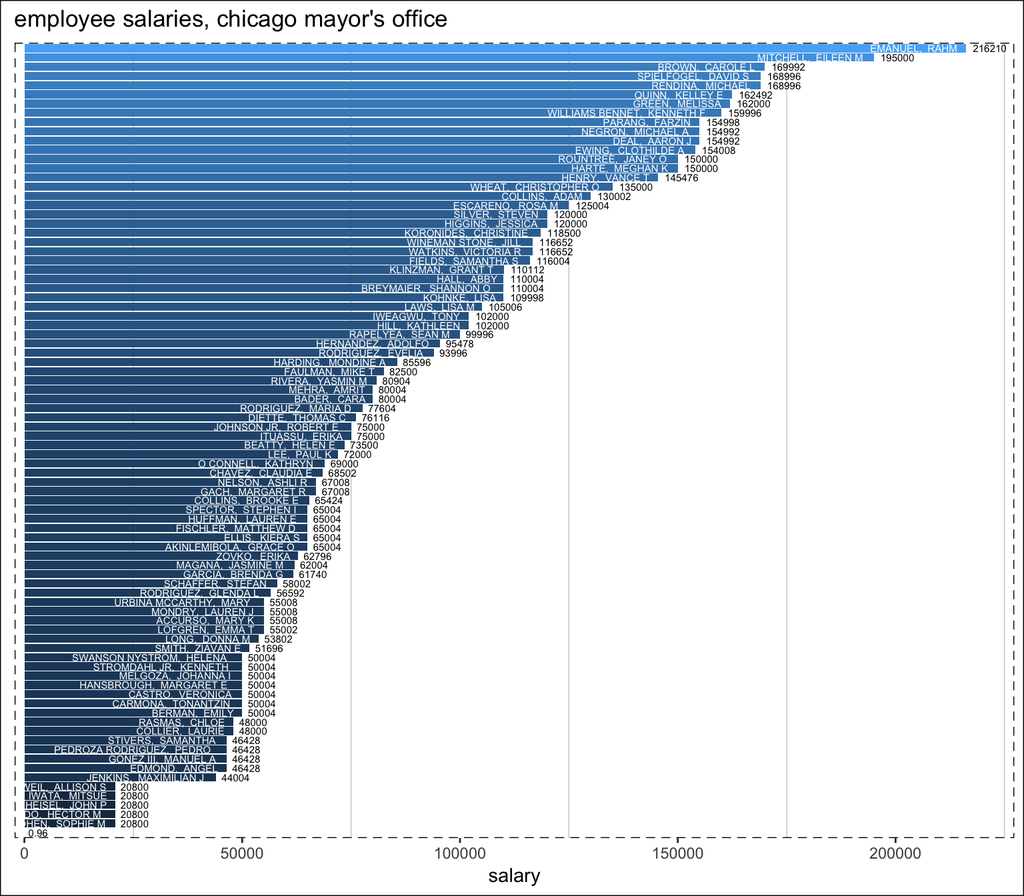

```r
# reminder: things that themes can modify: axes, legend, plot, panel, and strips (facet)
salaries %>%
  filter(dept == "MAYOR'S OFFICE") %>%
  mutate(pos = salary) %>%
  ggplot(aes(x = reorder(name, salary), y = salary, fill = salary)) +
  geom_bar(stat = "identity") +
  geom_text(aes(x = name, y = salary, label = name),
            color = "white",
            check_overlap = TRUE,
            na.rm = TRUE,
            size = 2, hjust = 1.1) +
  geom_text(aes(x = name, y = salary, label = salary),
            color = "black",
            check_overlap = TRUE,
            na.rm = TRUE,
            size = 2,
            hjust = -0.2) +
  scale_y_continuous(expand = c(0.01, 0), limits = c(0, 225000)) +
  coord_flip() +
  ggtitle("employee salaries, chicago mayor's office") +
  theme(plot.title = element_text(),
        axis.text.y = element_blank(),
        axis.ticks.y = element_blank(),
        axis.title.y = element_blank(),
        panel.background = element_blank(),
        panel.grid.major = element_blank(),
        panel.grid.minor = element_line(color = "gray80"),
        panel.ontop = FALSE, # puts gridlines on top of data
        plot.background = element_rect(fill = "white", color = "black"),
        panel.border = element_rect(linetype = "dashed", fill = NA),
        legend.position = "none")
```

We can see that the mayor, Rahm Emanuel, makes the most by far. Also, we are reminded of the reason for the extremely high standard deviation - we have Steven Koch, who’s only making $0.96.

So the mayor’s office has the second highest-paid city employee (the mayor) and the lowest paid employee (Steven Koch), which is why we see the highest standard deviation in this department.

Okay well, what about the department of Family & Support? We don’t have any $0.96/year salaries in that department.

```r
salaries %>%
  filter(dept == "FAMILY & SUPPORT") %>%
  select(Position = position, Salary = salary) %>%
  arrange(desc(Salary)) %>%
  datatable()
```

|  | Position | Salary |
| --- | --- | --- |
| 1 | COMMISSIONER OF FAMILY AND SUPPORT SERVICES | 175002 |
| 2 | DEPUTY COMMISSIONER | 134124 |
| 3 | FIRST DEPUTY COMMISSIONER | 131124 |
| 4 | AUDITOR IV | 116784 |
| 5 | DEPUTY COMMISSIONER | 115704 |
| 6 | DEPUTY COMMISSIONER | 113412 |
| 7 | DIR OF ADMINISTRATION | 111192 |
| 8 | DEPUTY COMMISSIONER | 111192 |
| 9 | PROGRAM DIR | 110088 |
| 10 | DIR OF HUMAN SERVICES | 110088 |

[output cut: 644 more lines]

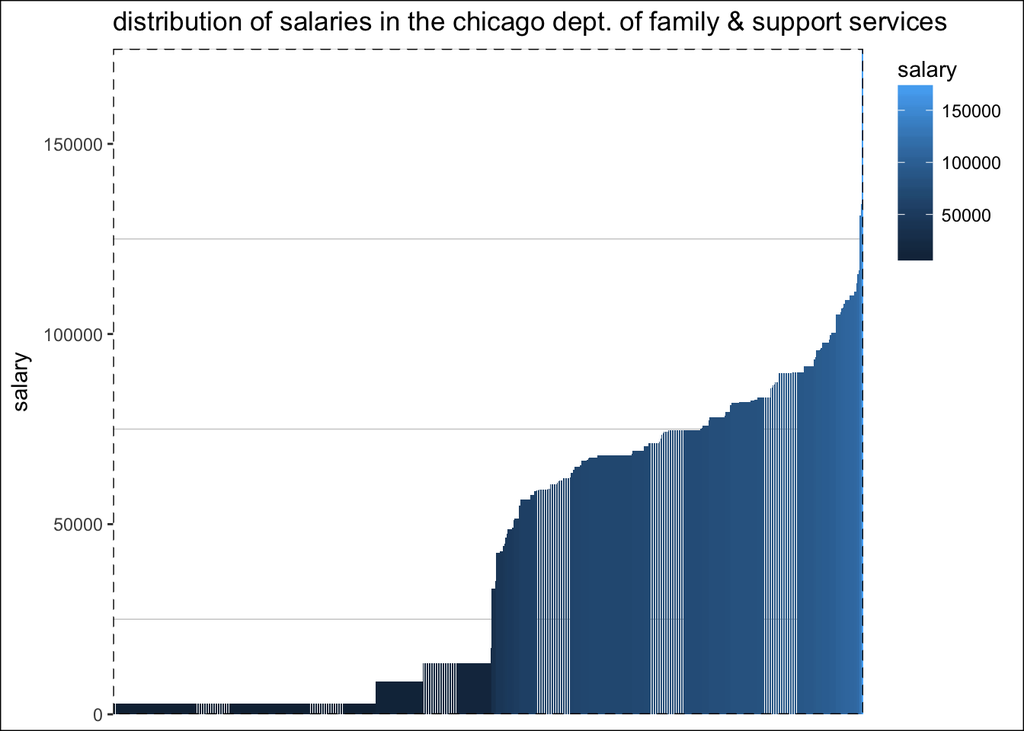

```r
salaries %>%
  filter(dept == "FAMILY & SUPPORT") %>%
  ggplot(aes(x = reorder(name,salary), y = salary, fill=salary)) +
  geom_bar(stat="identity") +
  ggtitle("distribution of salaries in the chicago dept. of family & support services") +
  scale_y_continuous(expand=c(0,0)) +
  theme(axis.text.x = element_blank(),
        axis.title.x = element_blank(),
        axis.ticks.x = element_blank(),
        plot.title = element_text(),
        panel.background = element_blank(),
        panel.grid.major = element_blank(),
        panel.grid.minor = element_line(color = "gray80"),
        panel.ontop = FALSE, # puts gridlines on top of data
        plot.background = element_rect(fill = "white", color = "black"),
        panel.border = element_rect(linetype = "dashed", fill = NA),
        legend.justification = "top")
```

```r
fs <- salaries %>%
  filter(dept == "FAMILY & SUPPORT")

mean(fs$salary < 10000)
```

```
## [1] 0.412844
```

```r
mean(fs$salary > 60000)
```

```
## [1] 0.4174312
```

By examining the distribution of salaries, we can see that there are about an even proportion of employees that make below $10,000 and more than $60,000. Because there are such a high number of low-paid employees in the F&S department, we get this level of standard deviation.

We noted that another department with a high standard deviation in salary was the Law department, so let’s also look into that.

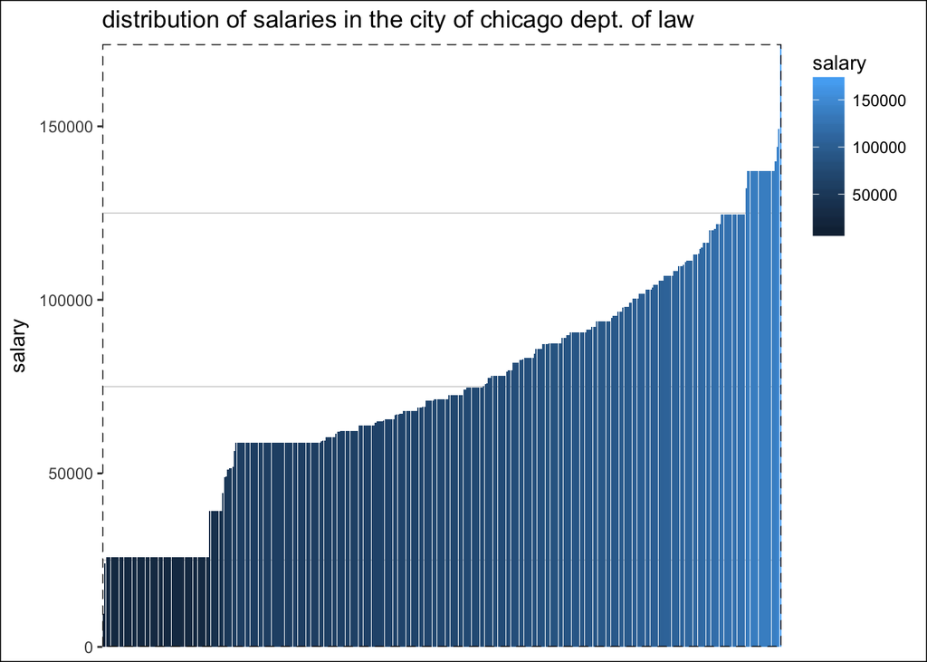

```r
salaries %>%
  filter(dept == "LAW") %>%
  ggplot(aes(x = reorder(name,salary), y = salary, fill=salary)) +
  geom_bar(stat="identity") +
  ggtitle("distribution of salaries in the city of chicago dept. of law") +
  scale_y_continuous(expand=c(0,0)) +
  theme(axis.text.x = element_blank(),
        axis.title.x = element_blank(),
        axis.ticks.x = element_blank(),
        plot.title = element_text(),
        panel.background = element_blank(),
        panel.grid.major = element_blank(),
        panel.grid.minor = element_line(color = "gray80"),
        panel.ontop = FALSE, # puts gridlines on top of data
        plot.background = element_rect(fill = "white", color = "black"),
        panel.border = element_rect(linetype = "dashed", fill = NA),
        legend.justification = "top")
```

Clearly we don’t see as much spread as there was in the Family & Support department, but overall the reason for this level of spread is the same; there’s a good proportion of employees at a much lower salary level with a similar proportion of employees at a higher salary level.

Okay, so we’ve spent some time understanding how salaries vary within departments, and have an idea now of which departments are most costly to the city of Chicago. Let’s finish up by answering our quirky but possibly interesting question:

### Grouped by first letter of first name, what letter earns the highest average salary?

```r
(salary_fname <- salaries %>%
  group_by("First Letter of First Name" = firstletter) %>%
  summarise("Average Salary" = round(mean(salary), 2)) %>%
  arrange(desc(`Average Salary`))) %>%
  datatable()
```

|  | First Letter of First Name | Average Salary |
| --- | --- | --- |
| 1 | W | 86094.49 |
| 2 | J | 83042.38 |
| 3 | T | 82849.5 |
| 4 | R | 82730.46 |
| 5 | P | 82650.69 |
| 6 | G | 81745.22 |
| 7 | F | 81458.35 |
| 8 | M | 81414.62 |
| 9 | K | 80805.98 |
| 10 | D | 80316.15 |

[output cut: 16 more lines]

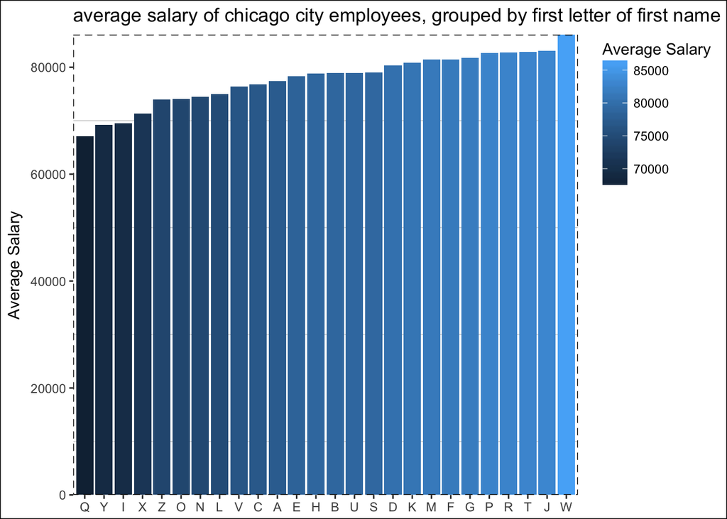

```r
salary_fname %>%
  ggplot(aes(x = reorder(`First Letter of First Name`, `Average Salary`), y = `Average Salary`, fill = `Average Salary`)) +
  geom_bar(stat="identity") +
  ggtitle("average salary of chicago city employees, grouped by first letter of first name") +
  scale_y_continuous(expand=c(0,0)) +
  theme(axis.title.x = element_blank(),
        plot.title = element_text(),
        panel.background = element_blank(),
        panel.grid.major = element_blank(),
        panel.grid.minor = element_line(color = "gray80"),
        panel.ontop = FALSE, # puts gridlines on top of data
        plot.background = element_rect(fill = "white", color = "black"),
        panel.border = element_rect(linetype = "dashed", fill = NA),
        legend.justification = "top")
```

Well, at least it doesn’t appear the city of Chicago is discriminating against people based on the letter that their first name starts with, at least in general.

Who has the highest salary among all individuals whose name starts with W?

```r
w <- subset(salaries, firstletter == 'W')
w[which.max(w$salary),]
```

```
## # A tibble: 1 × 9
##    last   first middle  position   dept salary             name
##   <chr>   <chr>  <chr>     <chr>  <chr>  <dbl>            <chr>
## 1  DUNN WILLIAM      P COMMANDER POLICE 162684 DUNN,  WILLIAM P
## # ... with 2 more variables: firstletter <chr>, last_firstletter <chr>
```

Turns out it’s the police commander, William P. Dunn.

But that wasn’t that interesting, so what about first letter of last name?

### Average salary, by first letter of last name

```r
(salary_lname <- salaries %>%
  group_by("First Letter of Last Name" = last_firstletter) %>%
  summarise("Average Salary" = round(mean(salary), 2)) %>%
  arrange(desc(`Average Salary`))) %>%
  datatable()
```

|  | First Letter of Last Name | Average Salary |
| --- | --- | --- |
| 1 | O | 85097.32 |
| 2 | K | 85023.36 |
| 3 | Q | 83859.74 |
| 4 | F | 82662.09 |
| 5 | N | 82030.09 |
| 6 | D | 81452.57 |
| 7 | Z | 81166.81 |
| 8 | M | 81113.18 |
| 9 | R | 80768.96 |
| 10 | E | 80661.45 |

[output cut: 16 more lines]

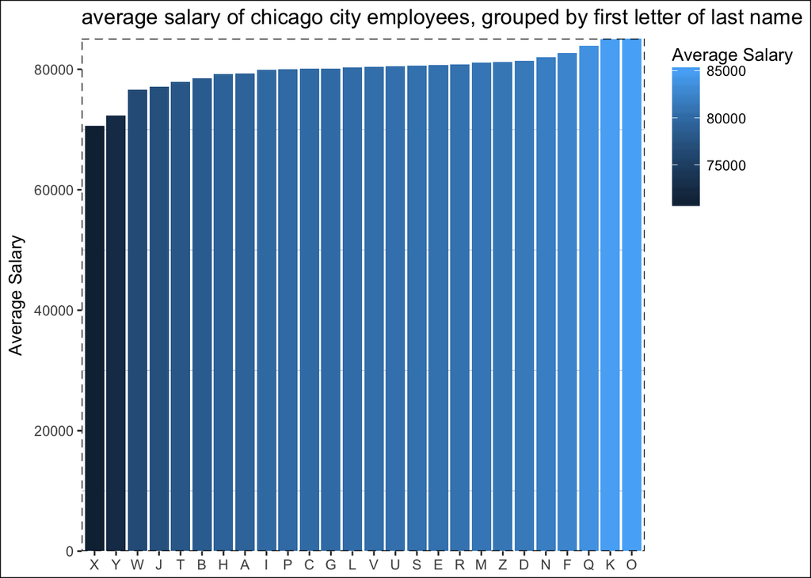

```r
salary_lname %>%
  ggplot(aes(x = reorder(`First Letter of Last Name`, `Average Salary`), y = `Average Salary`, fill = `Average Salary`)) +
  geom_bar(stat="identity") +
  ggtitle("average salary of chicago city employees, grouped by first letter of last name") +
  scale_y_continuous(expand=c(0,0)) +
  theme(axis.title.x = element_blank(),
        plot.title = element_text(),
        panel.background = element_blank(),
        panel.grid.major = element_blank(),
        panel.grid.minor = element_line(color = "gray80"),
        panel.ontop = FALSE, # puts gridlines on top of data
        plot.background = element_rect(fill = "white", color = "black"),
        panel.border = element_rect(linetype = "dashed", fill = NA),
        legend.justification = "top")
```

Ah, well. Worth a try. What I have learned is that maybe the luckiest people have first and last names that both start with ‘M’ - it’s within the highest positions in both groups! Yeah, probably just a coincidence, but…

### Anyway, here are some final key takeaways, to wrap everything up:

- Apparently there are actually real people in the world that have $1 annual salaries.
- The city of Chicago has a *lot* of police. But the nerds in IT are paid better.
- Running two airports also means that you’re the only one that gets to get paid more than the mayor. Who knew?